# Iqaluit flux cleaning

Kaj

2024-11-18

## IQ2 Flux Data Cleaning

Designed to clean EddyPro output variables collected at th Iqaluit 2 site,using cleaned biomet data and merged EddyPro output files created by IQ loading script

Uses original biomet variable names as created by datalogger, not FluxNet standardized biomet names.

Clear console and add packages

Loads cleaned biomet file created above and EddyPro flux data

```r
met = fread('C:/Users/klynoe/Documents/iqaluit_2/R_outputs/met/cleaned_met/IQ2biomet_cleaned.csv')

df = fread('C:/Users/klynoe/Documents/iqaluit_2/R_outputs/flux/IQ2_fluxes_merged_24.csv')

df$TIMESTAMP = df$ts

df= merge(df,met,by='TIMESTAMP',all = T, suffixes = c(".flux", ".met"))

rm(met)
```

Creates a variable to input a date range for the plots in the flux section

```r
flux_dates <- c('2024-03-01', '2024-09-30')
```

## Initial Clean

Initial Enegry Balance Analysis

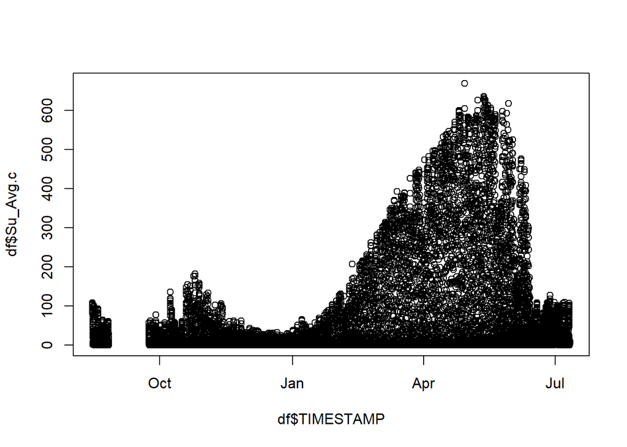

```r
df$shf = (df$SHFP_Avg_1.c + df$SHFP_Avg_2.c + df$SHFP_Avg_3.c)/3

df$met_EB = (df$long_dn_corr_Avg.c + df$Sd_Avg.c) - (df$long_up_corr_Avg.c + df$Su_Avg.c) + df$shf
df$flux_EB = df$H + df$LE


plot(df$TIMESTAMP,df$Su_Avg.c)
```

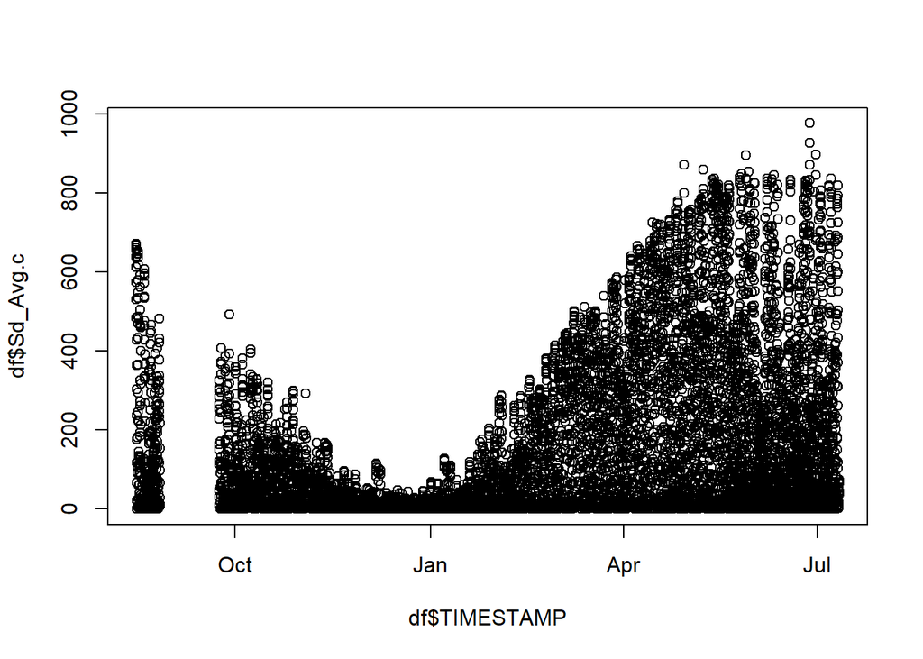

```r
plot(df$TIMESTAMP,df$Sd_Avg.c)
```

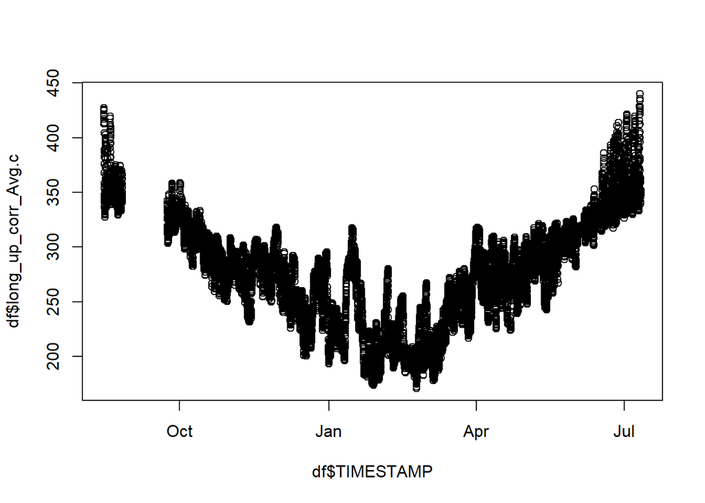

```r
plot(df$TIMESTAMP,df$long_up_corr_Avg.c)
```

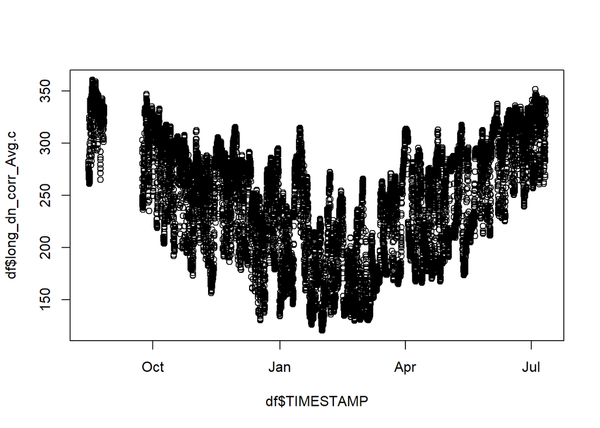

```r
plot(df$TIMESTAMP,df$long_dn_corr_Avg.c)
```

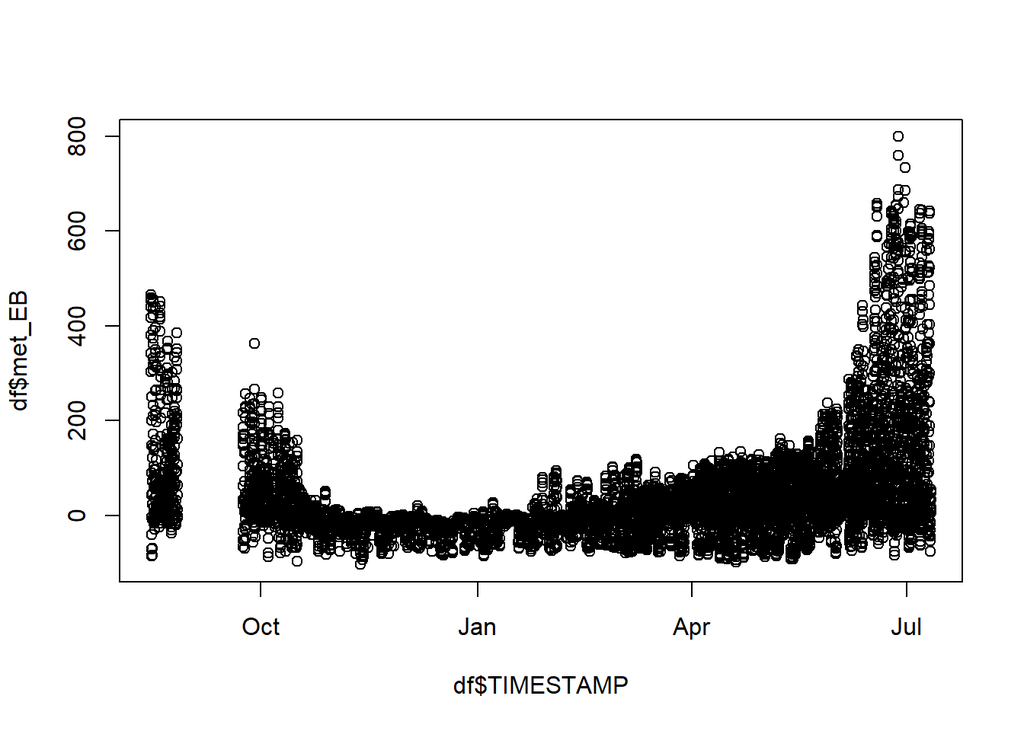

```r
plot(df$TIMESTAMP, df$met_EB)
```

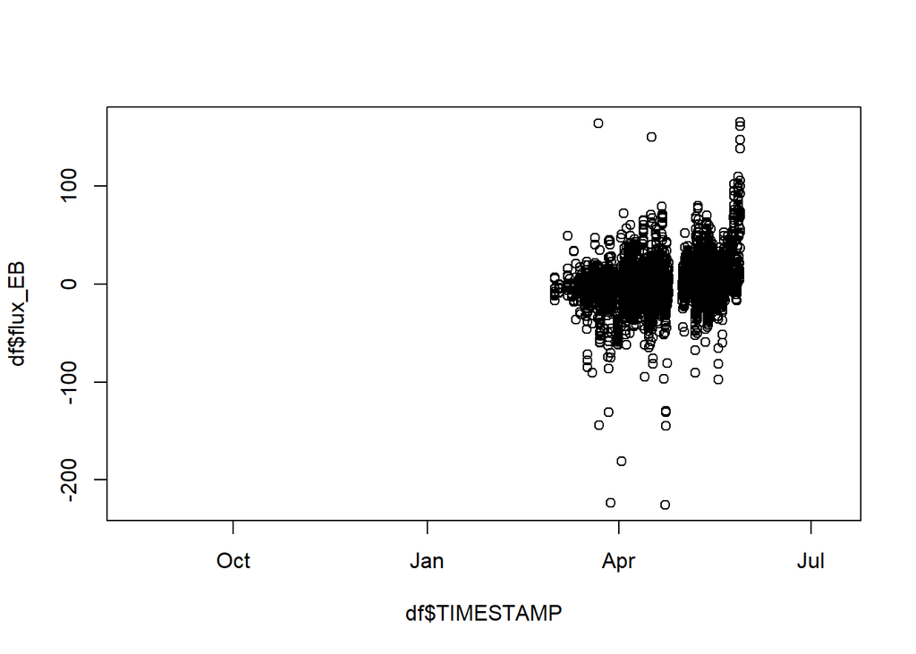

```r
plot(df$TIMESTAMP, df$flux_EB)
```

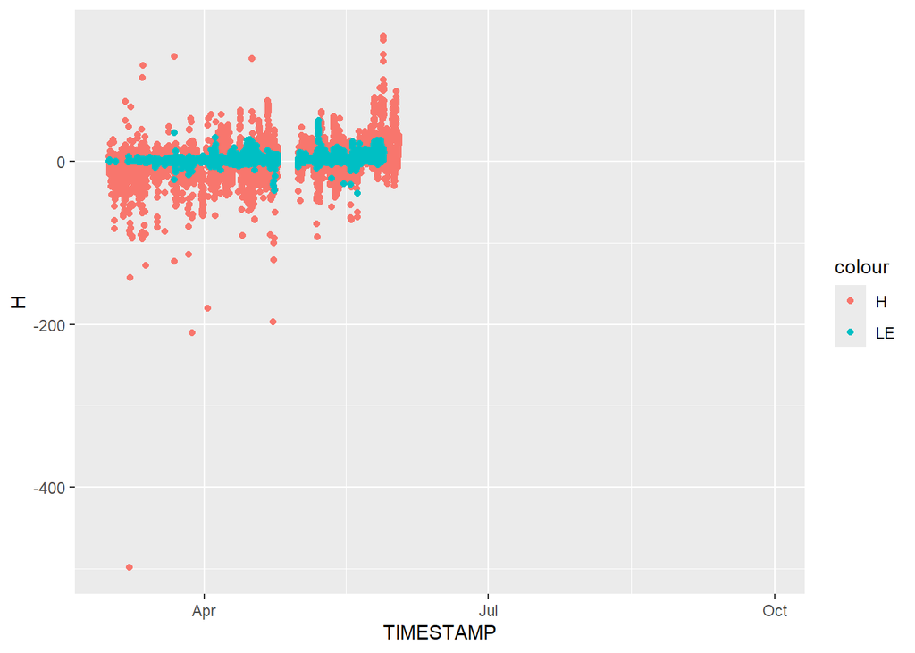

```r
ggplot(data = df)+
  geom_point(aes(TIMESTAMP,H,col='H'))+
  geom_point(aes(TIMESTAMP,LE,col='LE'))+
  scale_x_datetime(limits = as.POSIXct(flux_dates,format="%F"))
```

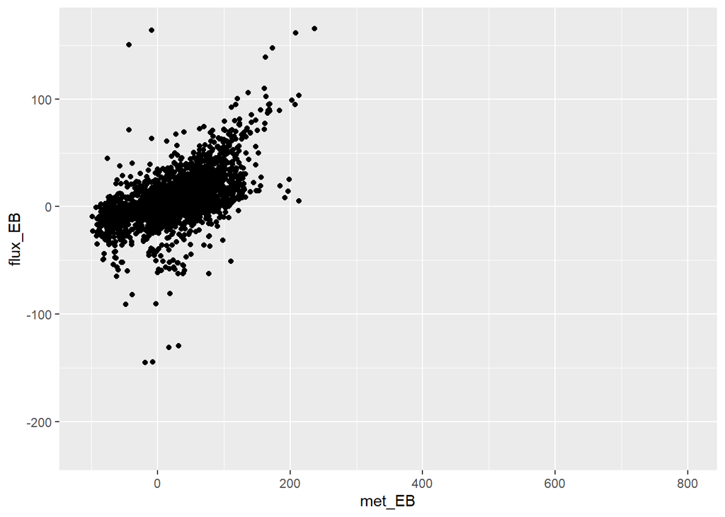

```r
ggplot(data = df,aes(met_EB,flux_EB))+
  geom_point()
```

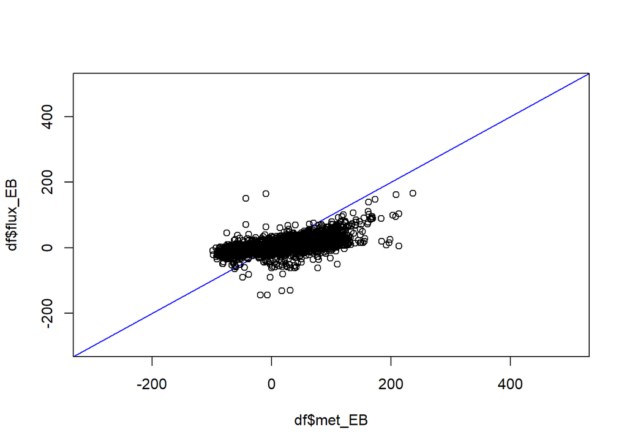

```r
plot(df$met_EB,df$flux_EB, abline(0, 1, col= 'blue'),xlim = c(-300,500),ylim = c(-300,500))
```

Statistical analysis of energy balance

```
##
## Call:
## lm(formula = df$flux_EB ~ df$met_EB)
##
## Residuals:
##      Min       1Q   Median       3Q      Max
## -142.851   -9.335   -0.601    9.377  166.345
##
## Coefficients:
##             Estimate Std. Error t value Pr(>|t|)
## (Intercept) 0.115785   0.455612   0.254    0.799
## df$met_EB   0.263278   0.007601  34.636   <2e-16 ***
## ---
## Signif. codes:  0 '***' 0.001 '**' 0.01 '*' 0.05 '.' 0.1 ' ' 1
##
## Residual standard error: 20.1 on 2386 degrees of freedom
##   (12284 observations deleted due to missingness)
## Multiple R-squared:  0.3346, Adjusted R-squared:  0.3343
## F-statistic:  1200 on 1 and 2386 DF,  p-value: < 2.2e-16
```

Filter by EddyPro quality flags to remove 2’s

```r
Tau.qc      = replace(df$Tau,df$qc_Tau == 2,NA)
co2_flux.qc = replace(df$co2_flux,df$qc_co2_flux == 2,NA)
ch4_flux.qc = replace(df$ch4_flux,df$qc_ch4_flux == 2,NA)
h2o_flux.qc = replace(df$h2o_flux,df$qc_h2o_flux == 2,NA)
LE.qc       = replace(df$LE,df$qc_LE == 2,NA)
H.qc        = replace(df$H,df$qc_H == 2,NA)
```

#### Tau

Looks fine, didn’t clean anything

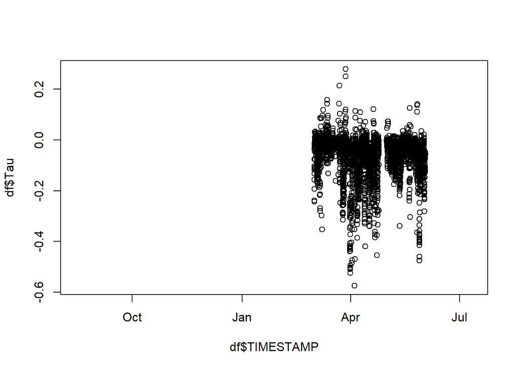

```r
plot(df$TIMESTAMP, df$Tau)
```

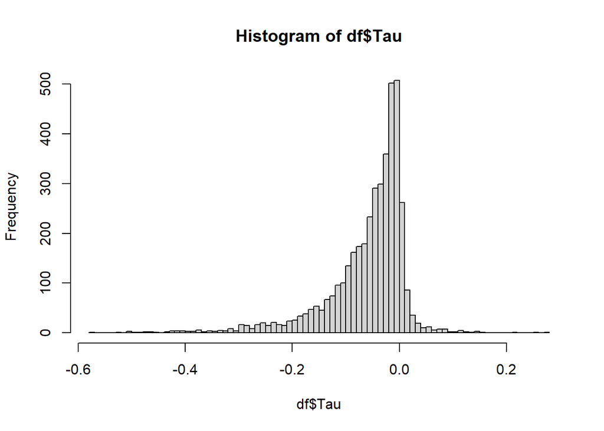

```r
hist(df$Tau,breaks=100)
```

```r
Tau.limits = df$Tau
```

#### NEE/CO<sub>2</sub> Flux

Initial Cleaning w/ Limits

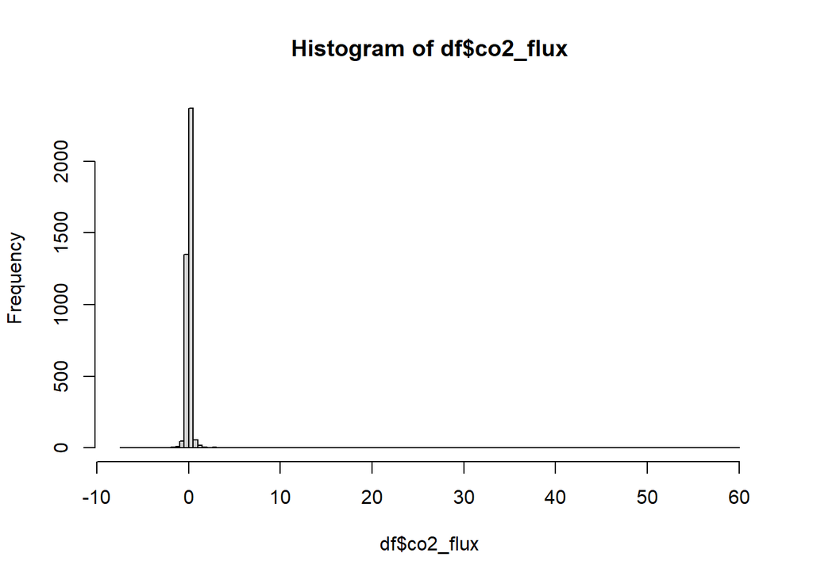

```r
hist(df$co2_flux,breaks=100)
```

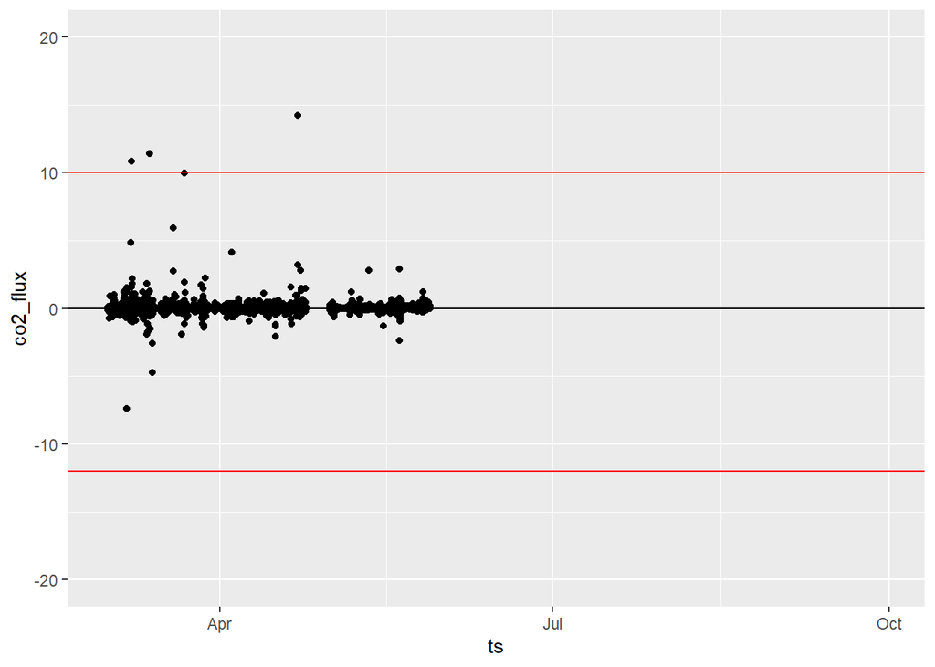

```r
upper_lim = 10
lower_lim = -12

ggplot(data = df)+geom_hline(yintercept = 0)+
  geom_point(aes(x=ts,y=co2_flux))+
  geom_hline(yintercept = upper_lim, col="red")+
  geom_hline(yintercept = lower_lim, col="red")+
  scale_y_continuous(limits = c(-20,20))+
  scale_x_datetime(limits = as.POSIXct(flux_dates,format="%F"))
```

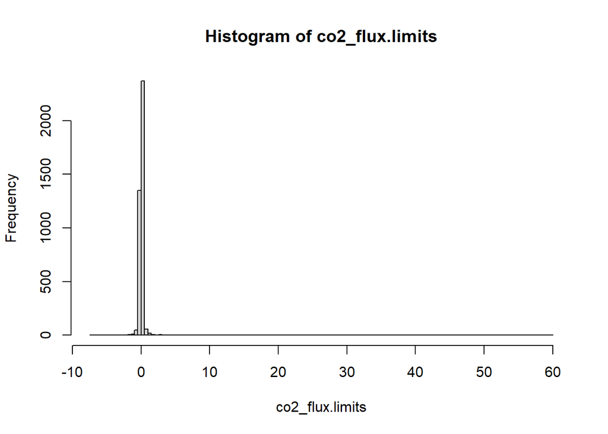

```r
co2_flux.limits = replace(df$co2_flux,df$co2_flux > upper_lim | df$co2$flux < lower_lim,NA)

hist(co2_flux.limits,breaks=100)
```

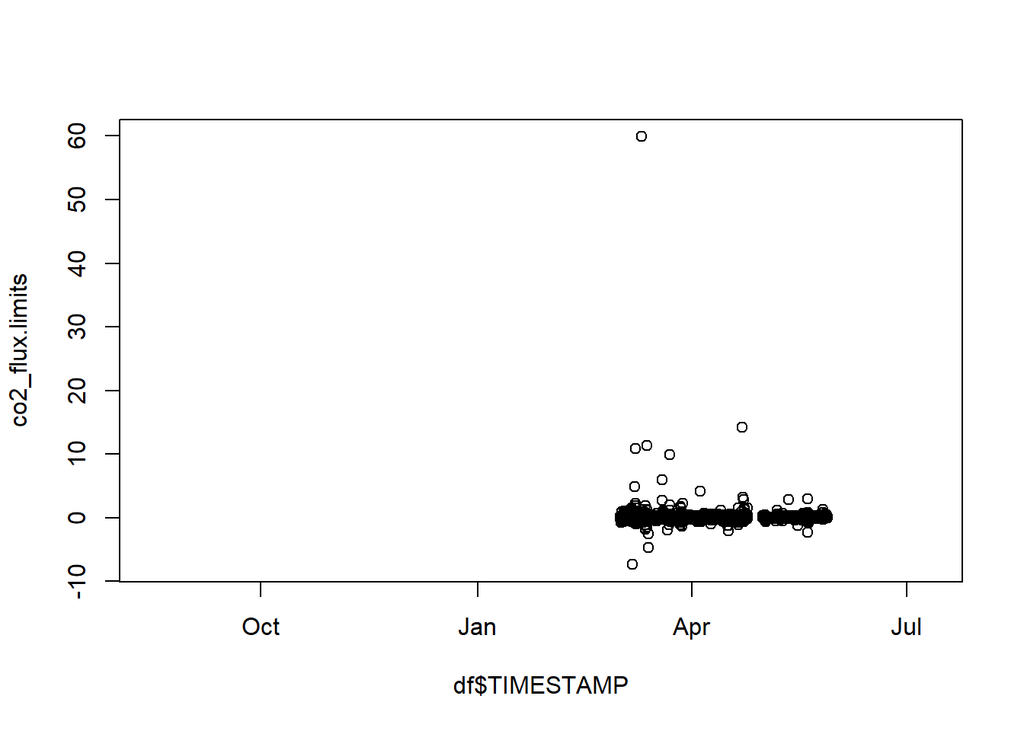

```r
plot(df$TIMESTAMP, co2_flux.limits)
```

#### H<sub>2</sub>O Flux

Initial Cleaning w/ Limits

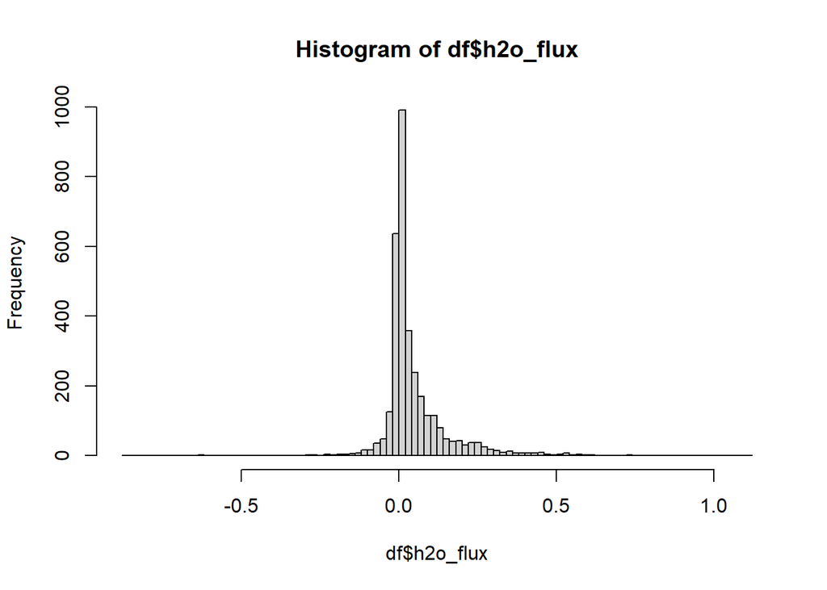

```r
hist(df$h2o_flux,breaks=100)
```

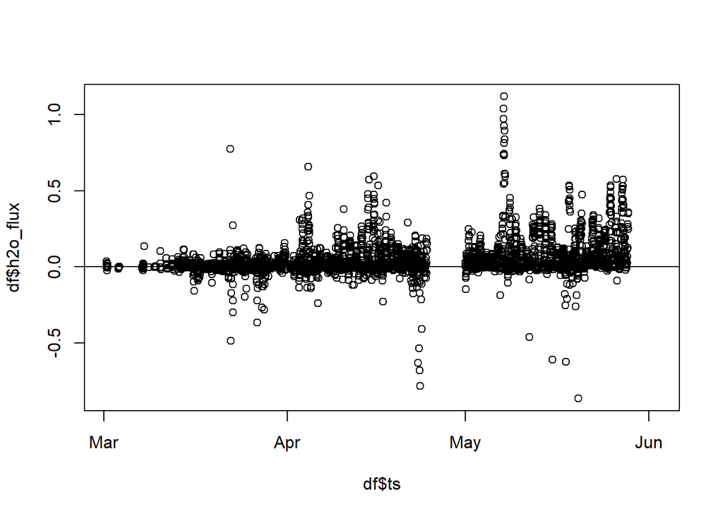

```r
plot(df$ts,df$h2o_flux, abline(h=-2, col= 'red')); abline(h=0,col= 'black')
```

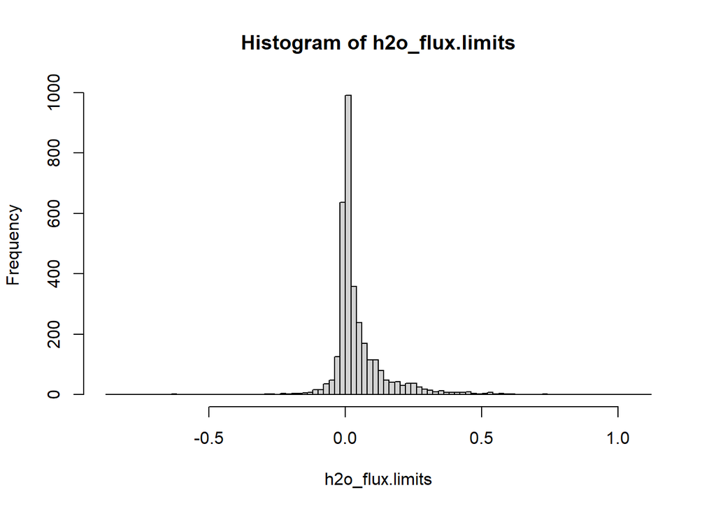

```r
h2o_flux.limits = replace(df$h2o_flux,df$h2o_flux < -1,NA)
hist(h2o_flux.limits,breaks=100)
```

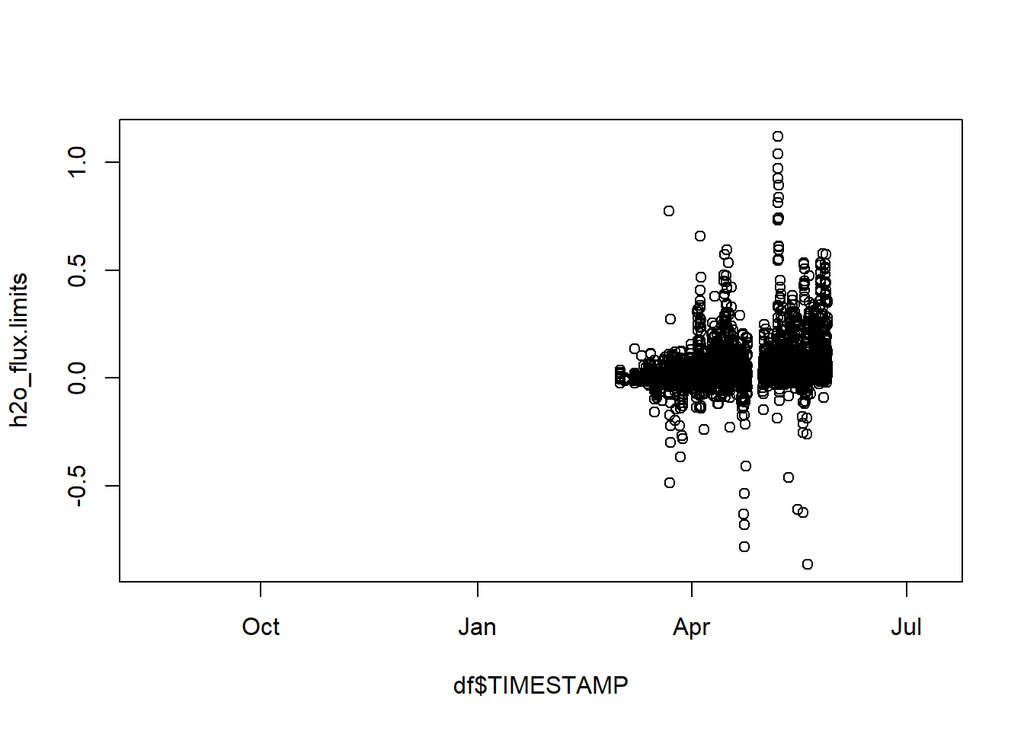

```r
plot(df$TIMESTAMP, h2o_flux.limits)
```

#### CH<sub>4</sub> Flux

Initial Cleaning w/ Limits

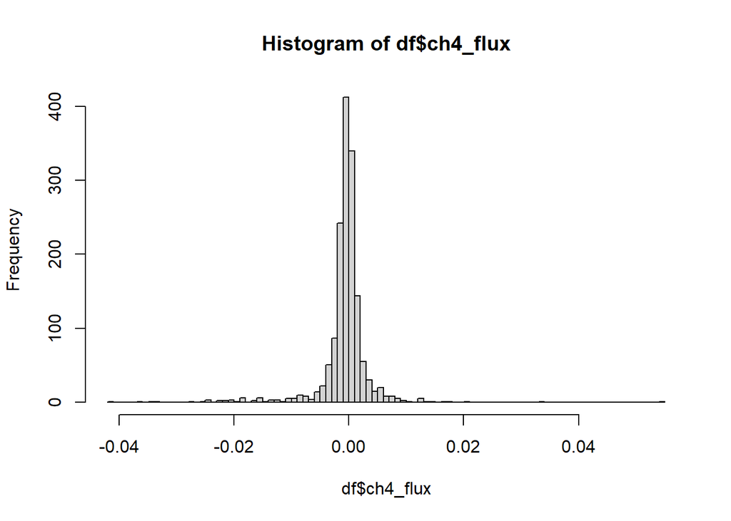

```r
hist(df$ch4_flux,breaks=100)
```

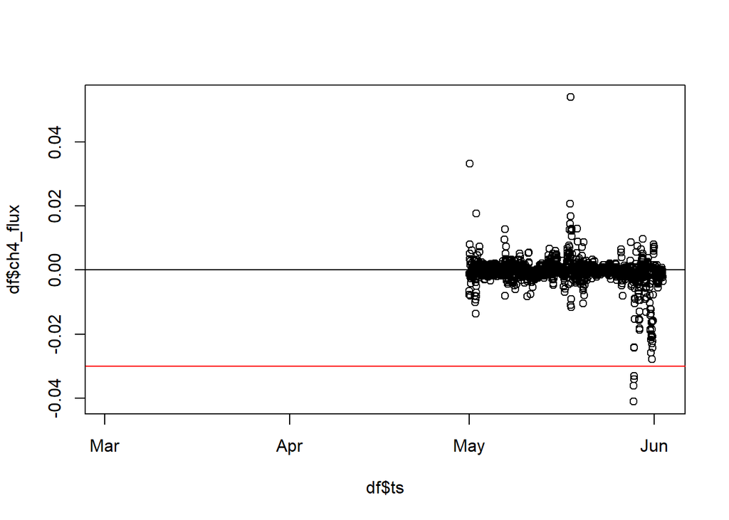

```r
plot(df$ts,df$ch4_flux); abline(h=0,col= 'black'); abline(h=-0.03, col='red')
```

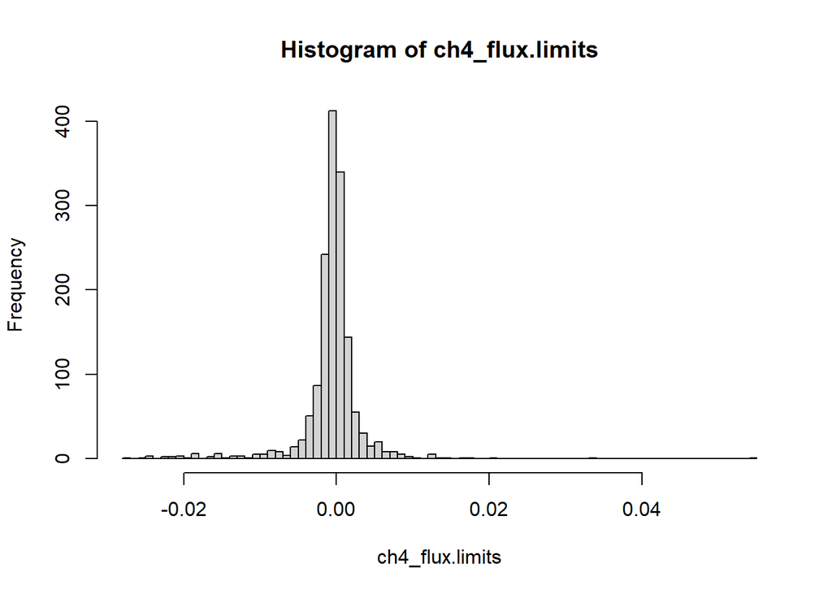

```r
# Clean based on graphs, create new variable (ch4_flux.limits), and see cleaned product

ch4_flux.limits = df$ch4_flux
ch4_flux.limits = replace(df$ch4_flux, df$ch4_flux < -0.03, NA)

hist(ch4_flux.limits,breaks = 100)
```

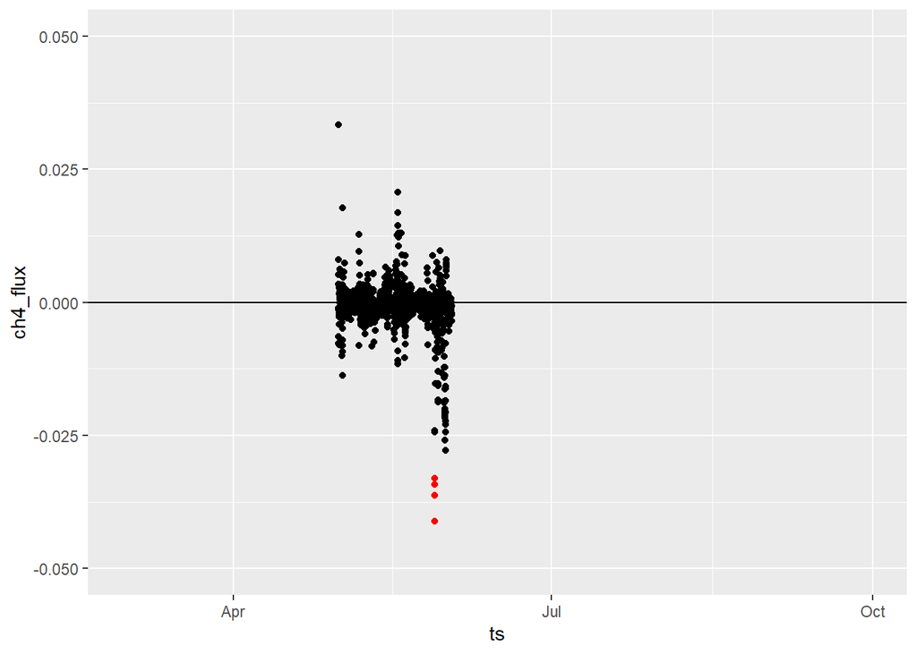

```r
ggplot(data = df)+geom_hline(yintercept = 0)+
  geom_point(aes(x=ts,y=ch4_flux),col = 'red')+
  geom_point(aes(x=ts,y=ch4_flux.limits),col = 'black')+
  scale_y_continuous(limits = c(-0.05, 0.05))+
  scale_x_datetime(limits = as.POSIXct(flux_dates,format="%F"))
```

#### H

Initial Cleaning w/ Limits

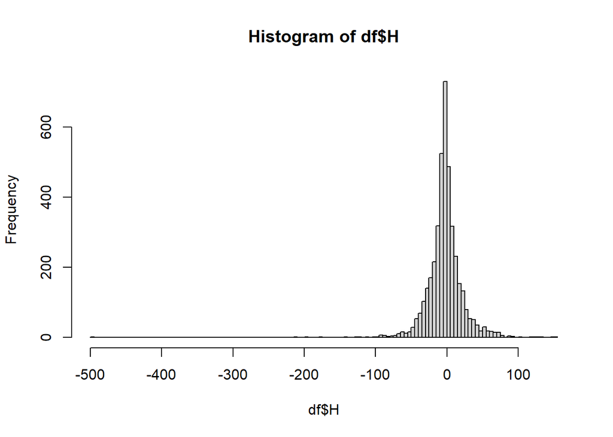

```r
hist(df$H,breaks=100)
```

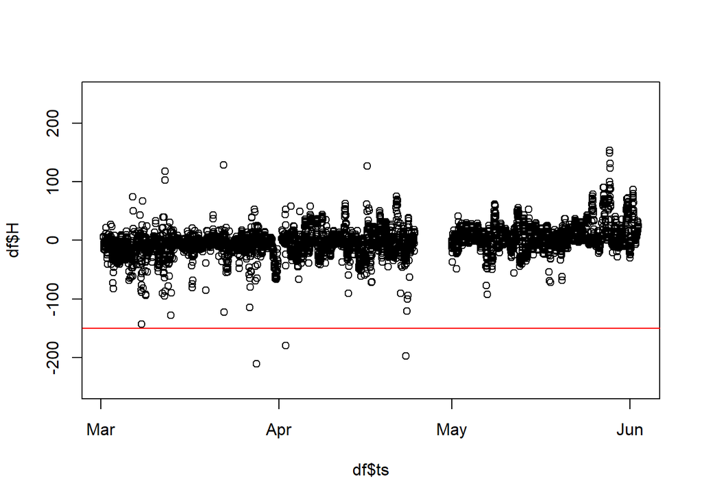

```r
plot(df$ts,df$H,ylim = c(-250,250));abline(h=-150, col= 'red')
```

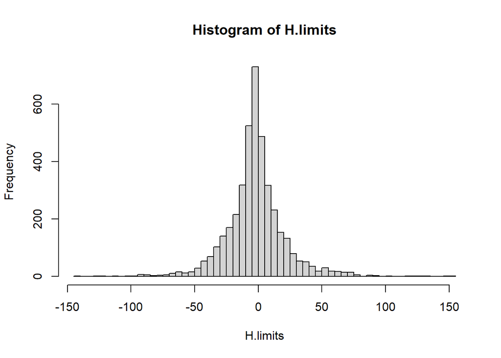

```r
# Clean based on graphs, create new variable (H.limits), and see cleaned product


H.limits = replace(df$H, df$H < -150,NA)
hist(H.limits,breaks = 100)
```

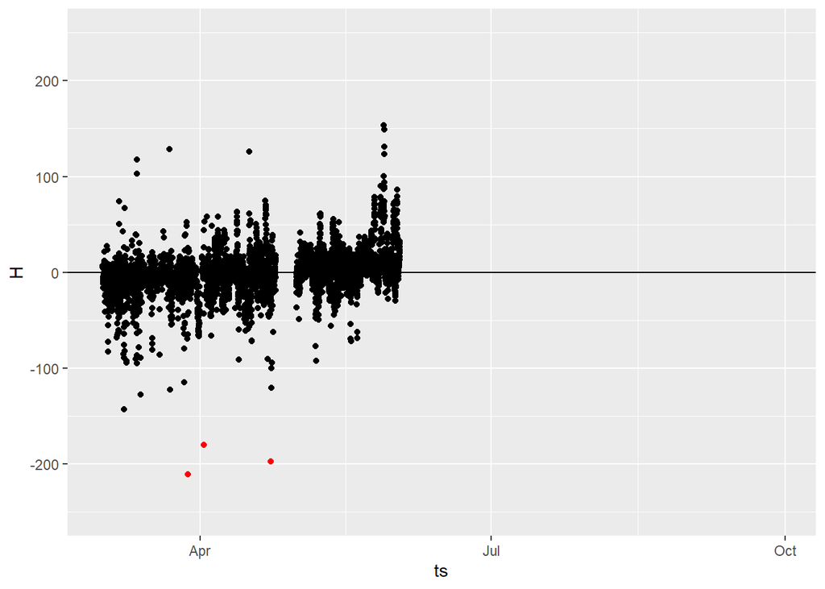

```r
ggplot(data = df)+geom_hline(yintercept = 0)+
  geom_point(aes(x=ts,y=H),col = 'red')+
  geom_point(aes(x=ts,y=H.limits),col = 'black')+
  scale_y_continuous(limits = c(-250,250))+
  scale_x_datetime(limits = as.POSIXct(flux_dates,format="%F"))
```

#### LE

Initial Cleaning w/ limits

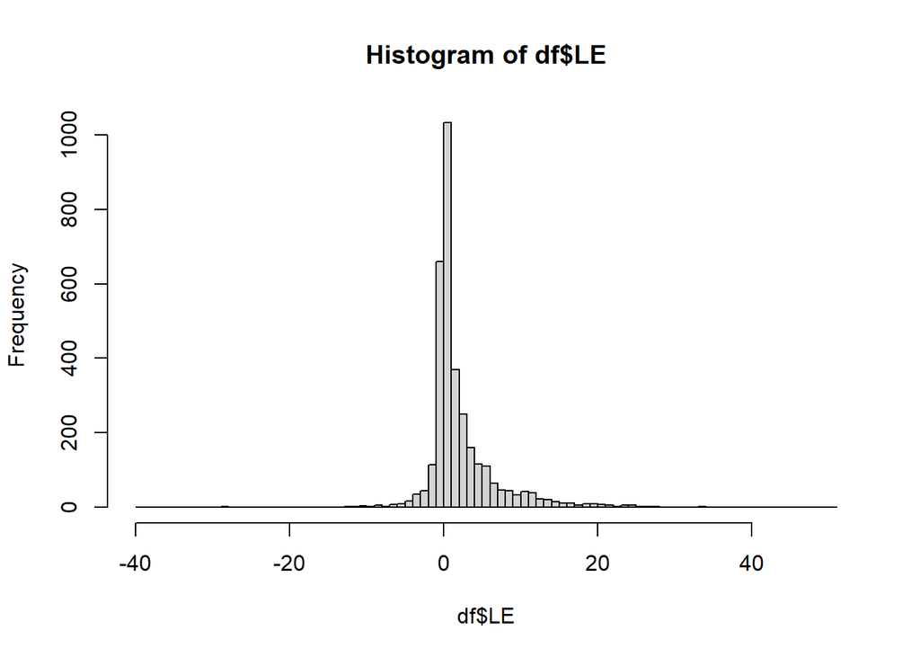

```r
hist(df$LE,breaks=100)
```

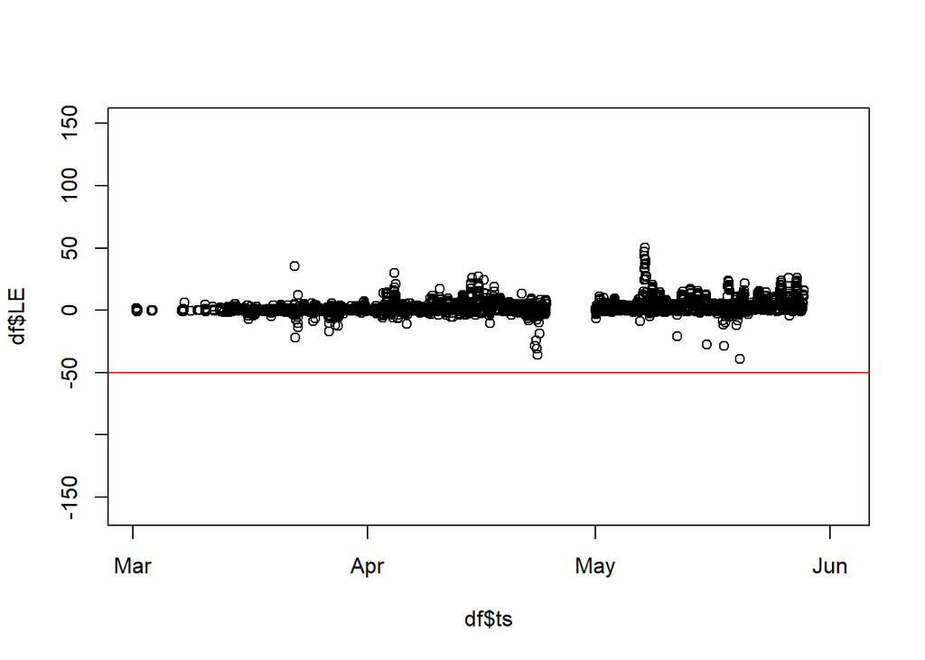

```r
plot(df$ts,df$LE,ylim = c(-160, 150));abline(h=-50, col= 'red')
```

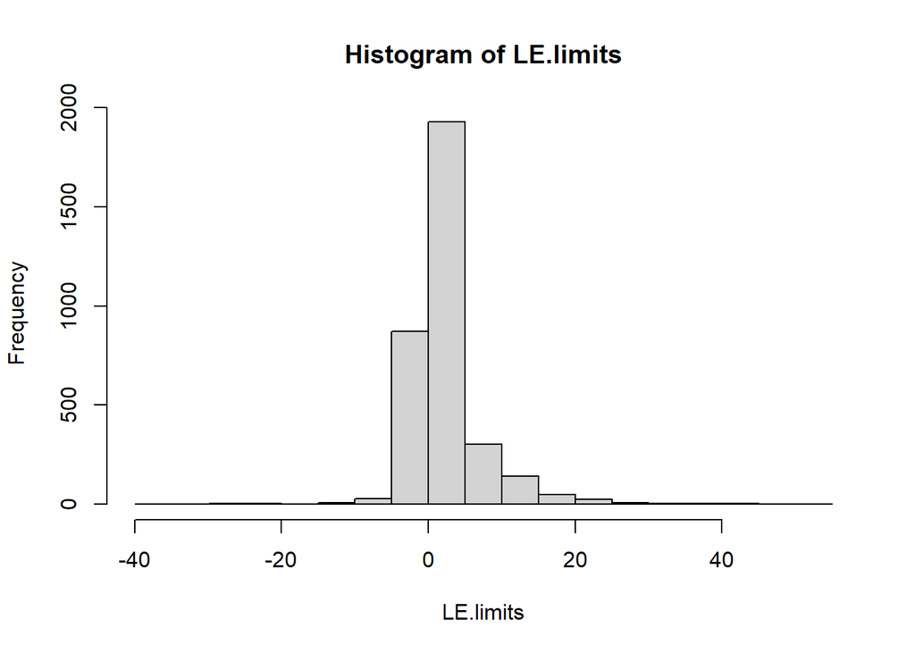

```r
# Clean based on graphs, create new variable (H.limits), and see cleaned product


LE.limits = replace(df$LE, df$LE < -50,NA)
hist(LE.limits)
```

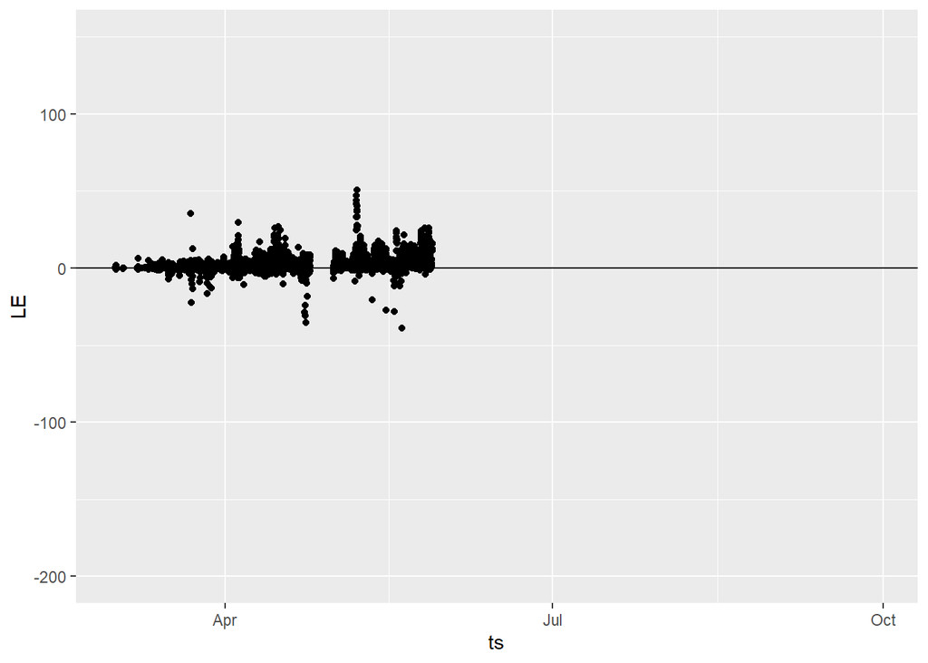

```r
ggplot(data = df)+geom_hline(yintercept = 0)+
  geom_point(aes(x=ts,y=LE),col = 'red')+
  geom_point(aes(x=ts,y=LE.limits),col = 'black')+
  scale_y_continuous(limits = c(-200,150))+
  scale_x_datetime(limits = as.POSIXct(flux_dates,format="%F"))
```